# MYLA Romidepsin + Afatinib Dimaleate Synergy RNA-seq analysis

RNA-seq analysis of MYLA CD4 cells treated with Romidepsin, Afatinib Dimaleate, or the Combination

For more details on how these samples were prepared go to OneNote > Drug Screen > RNA-seq + Annexin-V + Cell Cycle Analysis Romi + Afa Dim Combo > EXP 3 - MYLA

For more details on the alignment and count matrix generation, see /home/bobby/RStudio/RNA-seq/20220301_MYLA_RomiAfaSyn and open runSTAR.sh and runfeatureCounts.sh

```r
library(BiocManager)
library(DESeq2)
library(dplyr)
library(stringr)
library(pheatmap)
library(openxlsx)
library(RColorBrewer)
library(ggplot2)
library(ggpubr)
library(reshape2)
library(umap)
library(M3C)
library(circlize)
library(clusterProfiler)
```

```r
#Import count matrix generated from featureCounts
counts <- read.table('/home/bobby/RStudio/RNA-seq/20220301_MYLA_RomiAfaSyn/STAR/MYLA_RomiAfaDimSyn_countmatrix2.txt')

# Generate a count matrix removing all variant information from the ensembl gene ID
colnames(counts) <- counts[1,] # Make first row the column name
counts <- counts[-1,] # Remove the first row

# Remove unnecessary columns
counts$Chr <- NULL
counts$Start <- NULL
counts$End <- NULL
counts$Length <- NULL
counts$Strand <- NULL

counts <- counts[-which(duplicated(counts[,1])),] # Remove duplicated gene names
rownames(counts) <- counts[,1]
counts[,1] <- NULL

t_scale_counts <- t(counts) %>% as.data.frame() # Transpose count matrix
t_scale_counts <- as.data.frame(sapply(t_scale_counts, as.numeric)) # Convert transposed matrix to numeric for scale()
rownames(t_scale_counts) <- colnames(counts) # Unfortunately above code will reset rownames, revert to sample name
scale_counts <- t(scale(t_scale_counts))
scale_counts <- scale_counts[rowSums(is.na(scale_counts))==0,] # Remove NAs

scale_counts <- scale_counts[, c('DMSO-1', 'DMSO-2', 'DMSO-3', 'ROMI-1', 'ROMI-2', 'ROMI-3', 'AFADIM-1', 'AFADIM-2', 'AFADIM-3', 'COMBO-1', 'COMBO-2', 'COMBO-3')]
colnames(scale_counts) <- c("DMSO-1", "DMSO-2", "DMSO-3", "ROMI-1", "ROMI-2", "ROMI-3", "AFADIM-1", "AFADIM-2", "AFADIM-3", "COMBO-1", "COMBO-2", "COMBO-3")
write.csv(scale_counts, file = "/home/bobby/RStudio/RNA-seq/20220301_MYLA_RomiAfaSyn/DESEQ2/scale_counts.csv")
```

```r
DESEQ_counts <- counts
DESEQ_counts <- DESEQ_counts[!duplicated(DESEQ_counts$Geneid),]
rownames(DESEQ_counts) <- DESEQ_counts[,1]
DESEQ_counts[,1] <- NULL
DESEQ_counts <- data.matrix(DESEQ_counts)

#coldata is required information regrading each sample for analysis design
col.data <- read.csv("/home/bobby/RStudio/RNA-seq/20220301_MYLA_RomiAfaSyn/col.data.csv")
rownames(col.data) <- col.data[,1]
col.data[,1] <- NULL
col.data <- as.matrix(col.data)

# Run DESeq2 comparing each drug to dmso
dds_drug <- DESeqDataSetFromMatrix(countData = DESEQ_counts,
                              colData = col.data,
                              design = ~ drug)

# Look at a histogram of total counts to determine cutoff
dds_drug_count <- counts(dds_drug) %>% as.data.frame()
dds_drug_count$Gene <- rownames(dds_drug_count)
dds_drug_count <- data.frame(reshape::melt(dds_drug_count, id.vars = "Gene")) # Reshape the data for ggplot2

# VlnPlot of the counts by sample
ggplot(dds_drug_count, aes(x = variable, y = value)) +
  geom_violin(aes(fill = variable)) +
  scale_y_continuous(trans='log10') +
  theme_light() +
  theme(axis.text.x = element_text(angle = 45, hjust = 1), axis.title.x = element_blank(), legend.position = "none", axis.text = element_text(size = 11), axis.title.y = element_text(size = 14)) +
  ylab("Counts")

# Based on VlnPlots a cutoff of 10 is fine

remove <- apply(counts(dds_drug), 1, function(x) any(x <= 10)) #Remove all genes that have less than 10 counts in any condition as a pre-filtering step
dds_drug <- dds_drug[!remove,] # 13315 / 59048 genes kept
dds_drug$drug <- relevel(dds_drug$drug, ref = "dmso") # Set dmso as the reference
dds_drug <- DESeq(dds_drug) # Run DESEQ2

saveRDS(dds_drug, "/home/bobby/RStudio/RNA-seq/20220301_MYLA_RomiAfaSyn/DESEQ2/dds_drug.rds")
# dds_drug <- readRDS("/home/bobby/RStudio/RNA-seq/20220301_MYLA_RomiAfaSyn/DESEQ2/dds_drug.rds")

drug_romi_vs_dmso <- results(dds_drug, name = "drug_romi_vs_dmso")
drug_afa_vs_dmso <- results(dds_drug, name = "drug_afa_vs_dmso")
drug_combo_vs_dmso <- results(dds_drug, name = "drug_combo_vs_dmso")

dds_drug$drug <- relevel(dds_drug$drug, ref = "afa")
dds_drug <- DESeq(dds_drug)
drug_romi_vs_afa <- results(dds_drug, name = "drug_romi_vs_afa")
drug_combo_vs_afa <- results(dds_drug, name = "drug_combo_vs_afa")

dds_drug$drug <- relevel(dds_drug$drug, ref = "romi")
dds_drug <- DESeq(dds_drug)
drug_combo_vs_romi <- results(dds_drug, name = "drug_combo_vs_romi")
drug_afa_vs_romi <- results(dds_drug, name = "drug_afa_vs_romi")

write.csv(drug_romi_vs_dmso, file = "/home/bobby/RStudio/RNA-seq/20220301_MYLA_RomiAfaSyn/DESEQ2/drug_romi_vs_dmso.csv")
write.csv(drug_afa_vs_dmso, file = "/home/bobby/RStudio/RNA-seq/20220301_MYLA_RomiAfaSyn/DESEQ2/drug_afa_vs_dmso.csv")
write.csv(drug_combo_vs_dmso, file = "/home/bobby/RStudio/RNA-seq/20220301_MYLA_RomiAfaSyn/DESEQ2/drug_combo_vs_dmso.csv")
write.csv(drug_romi_vs_afa, file = "/home/bobby/RStudio/RNA-seq/20220301_MYLA_RomiAfaSyn/DESEQ2/drug_romi_vs_afa.csv")
write.csv(drug_combo_vs_afa, file = "/home/bobby/RStudio/RNA-seq/20220301_MYLA_RomiAfaSyn/DESEQ2/drug_combo_vs_afa.csv")
write.csv(drug_combo_vs_romi, file = "/home/bobby/RStudio/RNA-seq/20220301_MYLA_RomiAfaSyn/DESEQ2/drug_combo_vs_romi.csv")

#Export DESEQ2 normalized counts
dds_drug <- estimateSizeFactors(dds_drug)
counts(dds_drug, normalized = T) %>% write.csv(, file = "/home/bobby/RStudio/RNA-seq/20220301_MYLA_RomiAfaSyn/DESEQ2/DESEQ2_NormalizedCounts.csv")
```

[output not shown]

```r
all_pairwise_top_genes <- as.character()
colnames(all_pairwise_top_genes[,1]) <- 'X'

# Generate list of top 25 up- and down-regulated genes from each pairwise comparison (to DMSO)
all_pairwise_top_genes <- drug_combo_vs_dmso %>% as.data.frame() %>% subset(padj < 0.05) %>% top_n(n = 25, wt = log2FoldChange) %>% rownames() %>% c(all_pairwise_top_genes)
all_pairwise_top_genes <- drug_combo_vs_dmso %>% as.data.frame() %>% subset(padj < 0.05) %>% top_n(n = -25, wt = log2FoldChange) %>% rownames() %>% c(all_pairwise_top_genes)

all_pairwise_top_genes <- drug_romi_vs_dmso %>% as.data.frame() %>% subset(padj < 0.05) %>% top_n(n = 25, wt = log2FoldChange) %>% rownames() %>% c(all_pairwise_top_genes)
all_pairwise_top_genes <- drug_romi_vs_dmso %>% as.data.frame() %>% subset(padj < 0.05) %>% top_n(n = -25, wt = log2FoldChange) %>% rownames() %>% c(all_pairwise_top_genes)

all_pairwise_top_genes <- drug_afa_vs_dmso %>% as.data.frame() %>% subset(padj < 0.05) %>% top_n(n = 25, wt = log2FoldChange) %>% rownames() %>% c(all_pairwise_top_genes)
all_pairwise_top_genes <- drug_afa_vs_dmso %>% as.data.frame() %>% subset(padj < 0.05) %>% top_n(n = -25, wt = log2FoldChange) %>% rownames() %>% c(all_pairwise_top_genes)

all_pairwise_top_genes <- all_pairwise_top_genes[!(is.na(all_pairwise_top_genes))] # Remove NAs
all_pairwise_top_genes <- all_pairwise_top_genes[!(duplicated(all_pairwise_top_genes))] # Remove duplicated entries

# Generate matrix of scaled counts with genes selected based on log2FC from every possible pairwise comparison
all_pairwise_scaledcounts <- scale_counts[match(all_pairwise_top_genes, rownames(scale_counts)),] %>% as.data.frame()

# Re-order the columns
all_pairwise_scaledcounts <- all_pairwise_scaledcounts[, c('DMSO-1', 'DMSO-2', 'DMSO-3', 'ROMI-1', 'ROMI-2', 'ROMI-3', 'AFADIM-1', 'AFADIM-2', 'AFADIM-3', 'COMBO-1', 'COMBO-2', 'COMBO-3')]

# Generate heatmap
pheatmap(all_pairwise_scaledcounts,
         cluster_rows = TRUE,
         cluster_cols = FALSE,
         color = colorRampPalette(rev(brewer.pal(n = 7, name = "RdYlBu")))(100),
         show_rownames = FALSE,
         fontsize_col = 15,
         fontsize_row = 6,
         main = "MYLA",
         angle_col = 45)
```

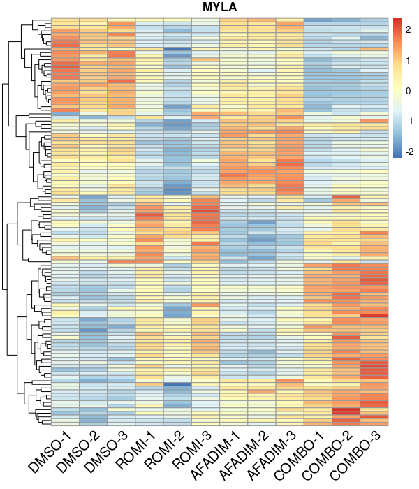

```r
knitr::include_graphics("/home/bobby/RStudio/RNA-seq/20220301_MYLA_RomiAfaSyn/DESEQ2/heatmap.png")
```

Calculate sample euclidian distance to understand variance in the data.

```r
# Transform counts using variance stabilizing transformation (VST) and regularized log transformation (RLT)
vsd <- vst(dds, blind=FALSE, fitType = 'local')
rld <- rlog(dds, blind=FALSE)
head(assay(vsd), 3)

# PCA plot to visualize variability in transcriptome as a result of treatment
plotPCA(vsd, intgroup = c("cell", "drug"), ntop = 500, returnData = FALSE)

# Heatmap of sample to sample distance
sampleDists <- dist(t(assay(vsd)))
library("RColorBrewer")
sampleDistMatrix <- as.matrix(sampleDists)
#rownames(sampleDistMatrix) <- paste(vsd$cell, vsd$drug, sep="-")
#colnames(sampleDistMatrix) <- NULL
colors <- colorRampPalette(rev(brewer.pal(9, "RdBu")))(255)
library(pheatmap)
pheatmap(sampleDistMatrix,
         cluster_cols = TRUE,
         show_colnames = FALSE,
         clustering_distance_rows=sampleDists,
         clustering_distance_cols=sampleDists,
         col=colors)
```

[output not shown]

Below was a pilot analysis applying UMAP dimensionality reduction to understand which genes specifically mediated the synergistic effect of Romidepsin + Afatinib Dimaleate combination treatment.

If there was, for instance, a set of genes that are not significantly perturbed between DMSO and Romi or DMSO and Afa Dim but was significantly dysregulated when comparing Romi vs. Combo and/or Afa Dim vs. Combo, this set of genes would be considered a combination specific effect of treatment.

One possible issue with conventional analysis of drug treatment when analyzing multiple drug treatments is that directly comparing DMSO and combination may uncover mechanisms of treatment that are caused by one of the single agent treatments alone, and is thus not considered combination specific. These mechanisms may be of interest, however the question being asked here is “which genes or sets of genes are specifically perturbed upon combination treatment not observed in either single agent treatment alone?”

In performing clustering and UMAP dimensionality reduction, we hope to provide an unbiased means of identifying combination specific mechanisms.

```r
UMAP_siggene_list <- drug_afa_vs_dmso %>% subset(abs(log2FoldChange) > 1.2 & padj < 0.05) %>% rownames()
UMAP_siggene_list <- drug_romi_vs_dmso %>% subset(abs(log2FoldChange) > 1.2 & padj < 0.05) %>% rownames() %>% c(UMAP_siggene_list)
UMAP_siggene_list <- drug_combo_vs_afa %>% subset(abs(log2FoldChange) > 1.2 & padj < 0.05) %>% rownames() %>% c(UMAP_siggene_list)
UMAP_siggene_list <- drug_afa_vs_romi %>% subset(abs(log2FoldChange) > 1.2 & padj < 0.05) %>% rownames() %>% c(UMAP_siggene_list)

UMAP_siggene_list <- UMAP_siggene_list[!duplicated(UMAP_siggene_list)] # Remove duplicated entries

UMAP_siggene_log2FC <- data.frame(row.names = UMAP_siggene_list)
UMAP_siggene_log2FC$afa_vs_dmso <- drug_afa_vs_dmso$log2FoldChange[match(rownames(UMAP_siggene_log2FC), rownames(drug_afa_vs_dmso))]
UMAP_siggene_log2FC$romi_vs_dmso <- drug_romi_vs_dmso$log2FoldChange[match(rownames(UMAP_siggene_log2FC), rownames(drug_romi_vs_dmso))]
UMAP_siggene_log2FC$combo_vs_afa <- drug_combo_vs_afa$log2FoldChange[match(rownames(UMAP_siggene_log2FC), rownames(drug_combo_vs_afa))]
UMAP_siggene_log2FC$combo_vs_romi <- drug_combo_vs_romi$log2FoldChange[match(rownames(UMAP_siggene_log2FC), rownames(drug_combo_vs_romi))]
UMAP_siggene_log2FC <- t(UMAP_siggene_log2FC)
UMAP_siggene_log2FC <- data.frame(UMAP_siggene_log2FC)

write.csv(UMAP_siggene_log2FC, file = "/home/bobby/RStudio/RNA-seq/20220301_MYLA_RomiAfaSyn/DESEQ2/UMAP/UMAP_siggene_log2FC.csv")

umap <- umap(UMAP_siggene_log2FC, dotsize = 1) # Uses the M3C package
saveRDS(umap, "/home/bobby/RStudio/RNA-seq/20220301_MYLA_RomiAfaSyn/DESEQ2/UMAP/umap.rds")
```

Run Monte Carlo Reference-based consensus clustering using the M3C package

```r
clusters <- M3C(UMAP_siggene_log2FC, cores = 32, method = 1) # Samples as columns (genes), rows as feature (DESEQ). Note that this may run into an error "undefined columns selected". This can be fixed by running the input data through data.frame()
saveRDS(clusters, "/home/bobby/RStudio/RNA-seq/20220301_MYLA_RomiAfaSyn/DESEQ2/UMAP/clusters.rds")
```

Save plots from clustering:

```r
# Save plots
png(filename = "/home/bobby/RStudio/RNA-seq/20220301_MYLA_RomiAfaSyn/DESEQ2/UMAP/CDF.png", width = 800, height = 400)
print(clusters$plots[[1]])
dev.off()

png(filename = "/home/bobby/RStudio/RNA-seq/20220301_MYLA_RomiAfaSyn/DESEQ2/UMAP/entropy.png", width = 800, height = 400)
print(clusters$plots[[2]])
dev.off()

png(filename = "/home/bobby/RStudio/RNA-seq/20220301_MYLA_RomiAfaSyn/DESEQ2/UMAP/pval.png", width = 800, height = 400)
print(clusters$plots[[3]])
dev.off()

png(filename = "/home/bobby/RStudio/RNA-seq/20220301_MYLA_RomiAfaSyn/DESEQ2/UMAP/RCSI.png", width = 800, height = 400)
print(clusters$plots[[4]])
dev.off()
```

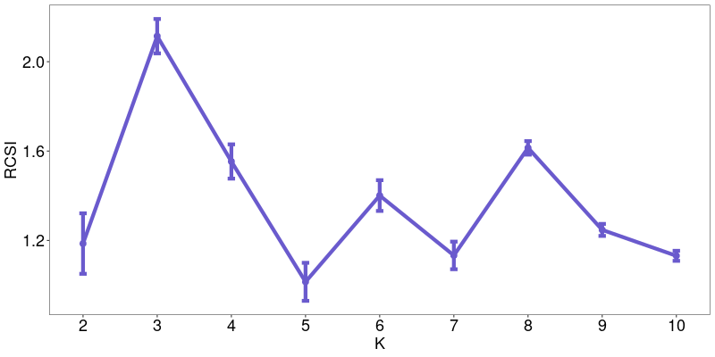

```r
knitr::include_graphics("/home/bobby/RStudio/RNA-seq/20220301_MYLA_RomiAfaSyn/DESEQ2/UMAP/RCSI.png")
```

Note that M3C will calculate various resolutions. Look at the graph using clusters$plots and access different assignments by using clusters$realdataresults[[n]]$assignments where n is the resolution desired

Based on RCSI plot a resolution of k = 3 is optimal

```r
data <- clusters$realdataresults[[3]]$ordered_data
annon <- clusters$realdataresults[[3]]$ordered_annotation
ccmatrix <- clusters$realdataresults[[3]]$consensus_matrix

assignments <- clusters$realdataresults[[3]]$assignments %>% as.data.frame()

umap_data <- umap$data
umap_data$assignment <- assignments[match(rownames(assignments), rownames(umap_data)),1]

# the below uses the output of the umap package
ggplot(umap_data, aes(x = umap_data[,1], y = umap_data[,2], color = as.factor(umap_data[,3]))) +
  geom_point() +
  theme_bw() +
  labs(x = "UMAP_1", y = "UMAP_2", color = "Cluster Assignment") +
  guides(colour = guide_legend(override.aes = list(size=5))) +
  theme(axis.text = element_text(size = 15),
        axis.title = element_text(size = 15),
        legend.text = element_text(size = 15),
        legend.title = element_text(size = 15))
```

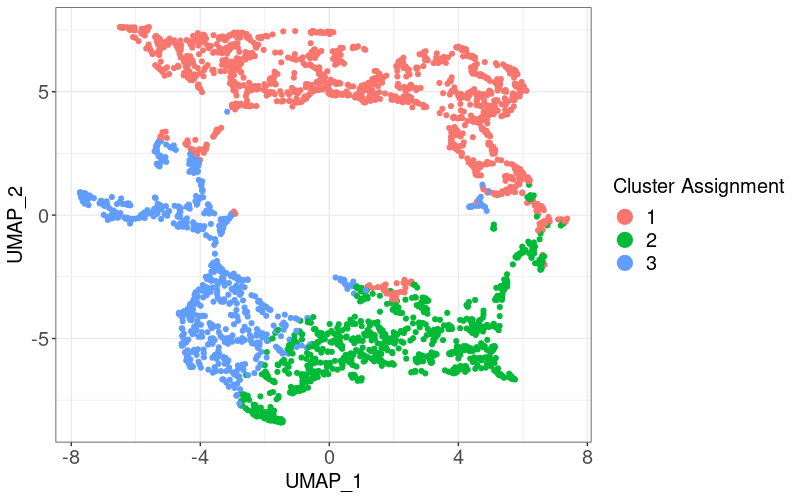

```r
knitr::include_graphics("/home/bobby/RStudio/RNA-seq/20220301_MYLA_RomiAfaSyn/DESEQ2/UMAP/UMAP_clustered.png")
```